# Assignment 3: Logistic Regression

```r
date()
```

```
## [1] "Tue Nov 22 03:10:51 2022"
```

## Data wrangling exercise

This time we joined two datasets together by their unique identifiers. I found the exercise useful though the wording ‘duplicates’ in the assignment kind of messed with my head since the ‘duplicates’ were actually different courses (portugal and math) which are unique values. As no output was needed in the course diary you can check the results of the data wrangling exercise [my data folder in the repo](https://github.com/jmlankinen/IODS-project/tree/master/data) if you wish to do so.

## Analysis

The purpose of this analysis is to study the relationships between high/low alcohol consumption and variables within a dataset.

### 1. Reading the data

```r
library(tidyverse)
library(GGally)
alc <- read.table("https://raw.githubusercontent.com/KimmoVehkalahti/Helsinki-Open-Data-Science/master/datasets/alc.csv", sep=",", header=TRUE)
glimpse(alc)
```

```
## Rows: 370
## Columns: 35
## $ school     <chr> "GP", "GP", "GP", "GP", "GP", "GP", "GP", "GP", "GP", "GP",…
## $ sex        <chr> "F", "F", "F", "F", "F", "M", "M", "F", "M", "M", "F", "F",…
## $ age        <int> 18, 17, 15, 15, 16, 16, 16, 17, 15, 15, 15, 15, 15, 15, 15,…
## $ address    <chr> "U", "U", "U", "U", "U", "U", "U", "U", "U", "U", "U", "U",…
## $ famsize    <chr> "GT3", "GT3", "LE3", "GT3", "GT3", "LE3", "LE3", "GT3", "LE…
## $ Pstatus    <chr> "A", "T", "T", "T", "T", "T", "T", "A", "A", "T", "T", "T",…
## $ Medu       <int> 4, 1, 1, 4, 3, 4, 2, 4, 3, 3, 4, 2, 4, 4, 2, 4, 4, 3, 3, 4,…
## $ Fedu       <int> 4, 1, 1, 2, 3, 3, 2, 4, 2, 4, 4, 1, 4, 3, 2, 4, 4, 3, 2, 3,…
## $ Mjob       <chr> "at_home", "at_home", "at_home", "health", "other", "servic…
## $ Fjob       <chr> "teacher", "other", "other", "services", "other", "other", …
## $ reason     <chr> "course", "course", "other", "home", "home", "reputation", …
## $ guardian   <chr> "mother", "father", "mother", "mother", "father", "mother",…
## $ traveltime <int> 2, 1, 1, 1, 1, 1, 1, 2, 1, 1, 1, 3, 1, 2, 1, 1, 1, 3, 1, 1,…
```

[output cut: 22 more lines]

The data we look into this exercise is about student alcohol consumption and its’ affect to student performance. Glimpse() function gives us a sneak peek into the dataset. It has 35 variables/columns which are in the following forms: integer, character, double and logical. The csv file in hand has been modified based on the data set found [here](https://archive.ics.uci.edu/ml/datasets/Student+Performance). The data is from a survey which was initially done to two different courses and in this modified csv file we’ve taken answers by students which were in both courses. The following adjustments have been made to the joined data set:

- The variables not used for joining the two data have been combined by averaging (including the grade variables)
- ‘alc_use’ is the average of ‘Dalc’ and ‘Walc’
- ‘high_use’ is TRUE if ‘alc_use’ is higher than 2 and FALSE otherwise

### 2. Hypothesis

We’re tasked to pick four interesting variables in the data and present a hypothesis about their relationships with alcohol consumption.

1. Students who consume a lot of alcohol (high_use) score lower in test than students who don’t.
2. Students’ whose father have a higher education level are less likely to consume alcohol than those with lower education.
3. Outgoing students are more likely to consume more alcohol
4. Male students are more likely to consume more alcohol than female students.

### 3. Exploring hypotheses

With hypotheses chosen we’ll numerically and graphically explore the chosen variables with a fitting way.

#### Alcohol consumption and test scores

```r
alc %>% group_by(high_use) %>% summarise(count = n(), median_grade = median(G3), mean_grade = mean(G3), Quartile11 = quantile(G3)[2], Quartile3 = quantile(G3)[4])
```

```
## # A tibble: 2 × 6
##   high_use count median_grade mean_grade Quartile11 Quartile3
##   <lgl>    <int>        <int>      <dbl>      <dbl>     <dbl>
## 1 FALSE      259           12       11.8         10        14
## 2 TRUE       111           11       10.9         10        12
```

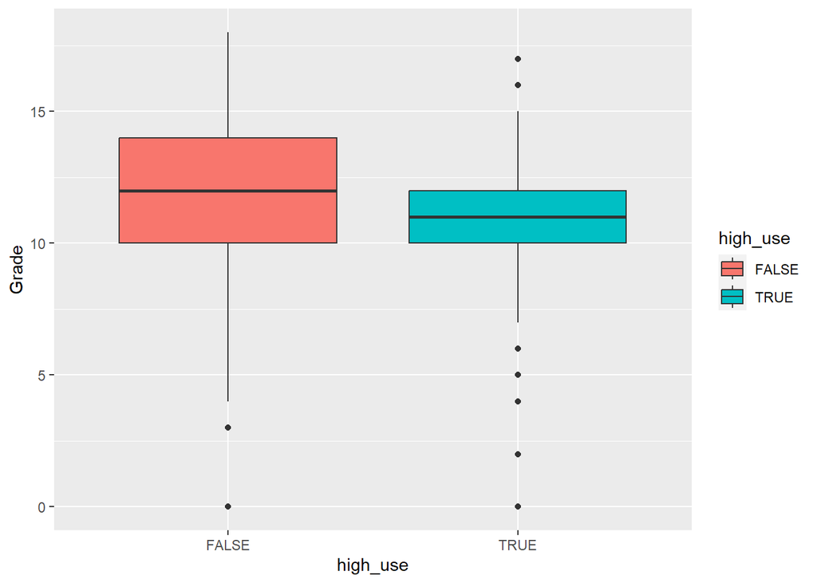

```r
g1 <- ggplot(alc, aes(x = high_use, y = G3, fill=high_use))
g1 + geom_boxplot() + ylab("Grade")
```

In the dataset there were 111 cases of high use alcohol (TRUE) consumers and 259 with less than 2 score of alcohol usage (FALSE). As expected high use of alcohol seems to have a negative effect on final test scores as the mean score is roughly 1 point less than the counterpart. High usage boxplot Q3 line is at the level of lower usage plot’s median. It’s also very tightly packed with 1st quartile & 3rd quartile being in the range of 10-12 compared to lower usage’s 10-14.

#### Father’s education’s affect on student’s alcohol consumption

```r
alc %>% group_by(Fedu, high_use) %>% summarise(count = n())
```

```
## # A tibble: 9 × 3
## # Groups:   Fedu [5]
##    Fedu high_use count
##   <int> <lgl>    <int>
## 1     0 FALSE        2
## 2     1 FALSE       49
## 3     1 TRUE        24
## 4     2 FALSE       75
## 5     2 TRUE        30
## 6     3 FALSE       70
## 7     3 TRUE        27
## 8     4 FALSE       63
## 9     4 TRUE        30
```

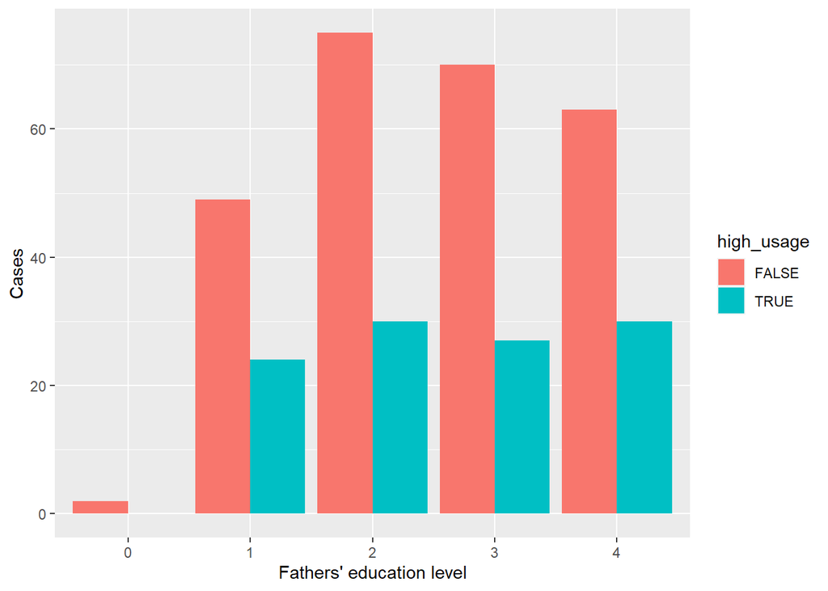

```r
#making a dataset based on summary
Fedudata <- data.frame(
  fedu = c("0", "0", "1", "1", "2", "2", "3", "3", "4", "4"),
  high_usage = c(FALSE, TRUE, FALSE, TRUE, FALSE, TRUE, FALSE, TRUE, FALSE, TRUE),
  count = c(2,0,49,24,75,30,70,27,63,30)
)

ggplot(Fedudata, aes(fill=high_usage, y=count, x=fedu)) + geom_bar(position="dodge", stat="identity") + xlab("Fathers' education level") + ylab("Cases")
```

We should exclude the 0 education level due it’s small sample size. It’s not evident from the bar graphs that father’s education level has a significant impact on student’s high usage of alcohol. In the first education level (primary school) the high usage is roughly the same as in the fourth education level (higher education). Interestingly education levels 2-3 seem to have a slightly smaller proportion of high usage alcohol consumers than in education levels 1 and 4. Out of interest I checked the effect on male students specifically and found a difference there:

```r
xtabs(~Fedu+high_use+sex, alc)
```

```
## , , sex = F
##
##     high_use
## Fedu FALSE TRUE
##    0     0    0
##    1    31   11
##    2    49    7
##    3    39   11
##    4    35   12
##
## , , sex = M
##
##     high_use
## Fedu FALSE TRUE
##    0     2    0
##    1    18   13
##    2    26   23
##    3    31   16
##    4    28   18
```

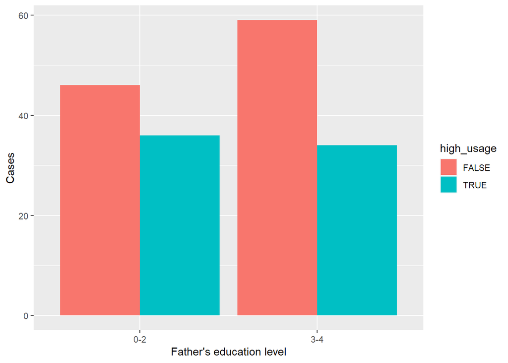

```r
#making a dataset based on summary of male students with father's grouped education levels 0-2 and 3-4
Fedudata <- data.frame(
  fedu = c("0-2", "0-2", "3-4", "3-4"),
  high_usage = c(FALSE, TRUE, FALSE, TRUE),
  count = c(46,36,59,34)
)

ggplot(Fedudata, aes(fill=high_usage, y=count, x=fedu)) + geom_bar(position="dodge", stat="identity") + xlab("Father's education level") + ylab("Cases")
```

Seems like father’s low education level increases the proportion of high usage alcohol consumers in male students.

#### Outgoing students consume more alcohol

```r
alc %>% group_by(goout, high_use) %>% summarise(count = n())
```

```
## # A tibble: 10 × 3
## # Groups:   goout [5]
##    goout high_use count
##    <int> <lgl>    <int>
##  1     1 FALSE       19
##  2     1 TRUE         3
##  3     2 FALSE       82
##  4     2 TRUE        15
##  5     3 FALSE       97
##  6     3 TRUE        23
##  7     4 FALSE       40
##  8     4 TRUE        38
##  9     5 FALSE       21
## 10     5 TRUE        32
```

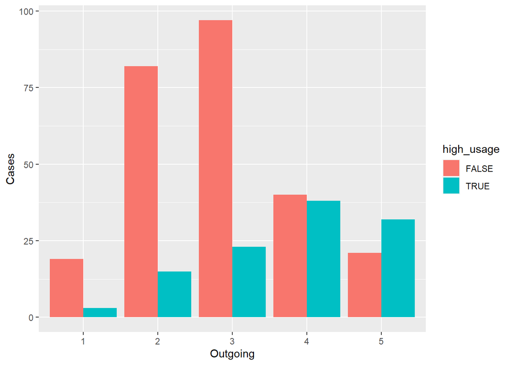

```r
#making a dataset based on summary
gooutdata <- data.frame(
  goout = c("1", "1", "2", "2", "3", "3", "4", "4", "5", "5"),
  high_usage = c(FALSE, TRUE, FALSE, TRUE, FALSE, TRUE, FALSE, TRUE, FALSE, TRUE),
  count = c(19,3,82,15,97,23,40,38,21,32)
)

ggplot(gooutdata, aes(fill=high_usage, y=count, x=goout)) + geom_bar(position="dodge", stat="identity") + xlab("Outgoing") + ylab("Cases")
```

Again we can see the hypothesis was accurate. In the outgoing levels of 1-3 (very low to moderate) the gap between high usage and low usage is noticeable. At Outgoing level 4 questionnaires are roughly split and the most outgoing students are more likely to be high usage consumers than low usage.

#### Alcohol consumption male vs female

```r
xtabs(~alc_use+sex, alc)
```

```
##        sex
## alc_use  F  M
##     1   87 53
##     1.5 41 22
##     2   26 30
##     2.5 25 16
##     3   11 21
##     3.5  3 14
##     4    1  8
##     4.5  0  3
##     5    1  8
```

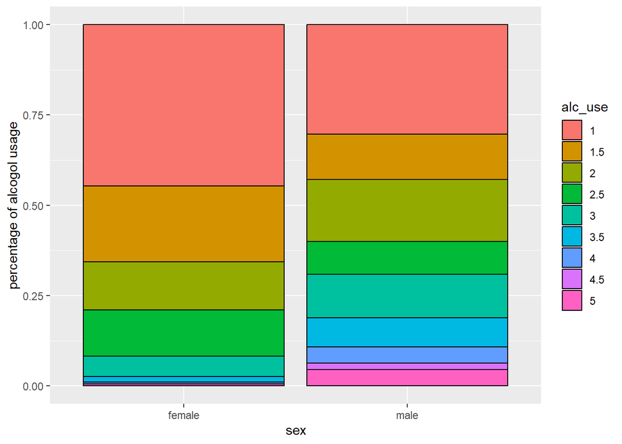

```r
#making a dataset based on xtabs
alc_use_data <- data.frame(
  alc_use = c("1", "1.5", "2", "2.5", "3", "3.5", "4", "4.5", "5", "1", "1.5", "2", "2.5", "3", "3.5", "4", "4.5", "5"),
  sex = c("male", "male", "male", "male", "male", "male", "male", "male", "male", "female", "female", "female", "female", "female", "female", "female", "female", "female"),
  count = c(53, 22, 30, 16, 21, 14, 8, 3, 8, 87, 41, 26, 25, 11, 3, 1, 0, 1)
)
#plotting the dataset
ggplot(alc_use_data, aes(fill=alc_use, y=count, x=sex)) + geom_bar(position="fill", stat="identity", colour="black") + xlab("sex") + ylab("percentage of alcogol usage")
```

Here we’ve plotted the alcolohol usage (1-5) as percentages of female and male students. Out of interest I specifically plotted the whole spectrum of usage (1-5) rather than the low/high usage. We can see from the bar graph that for females the low alcohol usage values from 1-2 correspond around 80% of the female students where as 1-2 corresponds 60% of male students. It’s safe to say that male students are more likely to consume high amounts of alcohol based on the graphs.

### 4. Logistic regression model

As instructed in the assignment we’ll use the variables used in hypotheses: G3 (final grade), Fedu (father’s education level), goout (‘outgoingness’ of student) & sex.

```r
# fitting the model & showing the summary
model <- glm(high_use ~ G3+Fedu+goout+sex, data = alc, family = "binomial")
summary(model)
```

```
##
## Call:
## glm(formula = high_use ~ G3 + Fedu + goout + sex, family = "binomial",
##     data = alc)
##
## Deviance Residuals:
##     Min       1Q   Median       3Q      Max
## -1.7543  -0.8370  -0.5729   0.8470   2.4756
##
## Coefficients:
##             Estimate Std. Error z value Pr(>|z|)
## (Intercept) -3.11758    0.69387  -4.493 7.02e-06 ***
## G3          -0.05695    0.03971  -1.434 0.151543
## Fedu         0.01864    0.11768   0.158 0.874114
## goout        0.72848    0.12015   6.063 1.33e-09 ***
## sexM         0.92443    0.25155   3.675 0.000238 ***
## ---
## Signif. codes:  0 '***' 0.001 '**' 0.01 '*' 0.05 '.' 0.1 ' ' 1
##
## (Dispersion parameter for binomial family taken to be 1)
##
##     Null deviance: 452.04  on 369  degrees of freedom
## Residual deviance: 386.86  on 365  degrees of freedom
## AIC: 396.86
##
## Number of Fisher Scoring iterations: 4
```

```r
# coefficients as odds ratios
odds_ratios <- coef(model) %>% exp

# confidence intervals
ci <- confint(model)
cbind(odds_ratios, ci)
```

```
##             odds_ratios      2.5 %      97.5 %
## (Intercept)  0.04426403 -4.5230245 -1.79503224
## G3           0.94464549 -0.1353284  0.02081591
## Fedu         1.01881957 -0.2121214  0.25031565
## goout        2.07192893  0.4991020  0.97114863
## sexM         2.52041925  0.4362474  1.42438709
```

#### Predictive power of the model

```r
#dropping Fedu and G3 from the moodel
model2 <- glm(high_use ~ goout+sex, data = alc, family = "binomial")

#mutating the original table with model's predictions
alc <- mutate(alc, probability = predict(model2, type = "response"))
alc <- mutate(alc, prediction = probability > 0.5)
#showing the last 10 rows
select(alc, goout, sex, high_use, probability, prediction) %>% tail(10)
```

```
##     goout sex high_use probability prediction
## 361     3   M    FALSE  0.34999869      FALSE
## 362     2   M    FALSE  0.20151317      FALSE
## 363     3   M     TRUE  0.34999869      FALSE
## 364     3   F    FALSE  0.17569180      FALSE
## 365     3   F    FALSE  0.17569180      FALSE
## 366     2   F    FALSE  0.09082261      FALSE
## 367     4   F    FALSE  0.31259947      FALSE
## 368     1   F    FALSE  0.04472568      FALSE
## 369     5   M     TRUE  0.71024877       TRUE
## 370     1   M     TRUE  0.10577129      FALSE
```

If probability is over 0.5 then the model predicts that alcohol consumption is high (TRUE). Let’s visualize the actual values and predictions

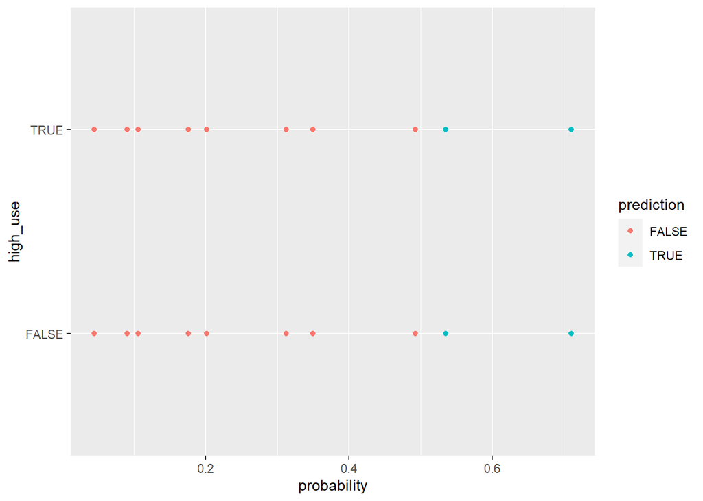

```r
#plotting the actual values vs predictions
ggplot(alc, aes(x = probability, y = high_use, col = prediction)) + geom_point()
```

```r
#tabulating target variable vs prediction
table(high_use = alc$high_use, prediction = alc$prediction)
```

```
##         prediction
## high_use FALSE TRUE
##    FALSE   242   17
##    TRUE     62   49
```

```r
# tabulate the target variable versus the predictions with proportions
table(high_use = alc$high_use, prediction = alc$prediction) %>%  prop.table() %>%  addmargins()
```

```
##         prediction
## high_use      FALSE       TRUE        Sum
##    FALSE 0.65405405 0.04594595 0.70000000
##    TRUE  0.16756757 0.13243243 0.30000000
##    Sum   0.82162162 0.17837838 1.00000000
```

```r
#mean prediction error function
loss_func <- function(class, prob) {
  n_wrong <- abs(class - prob) > 0.5
  mean(n_wrong)
}

loss_func(class = alc$high_use, prob = alc$probability)
```

```
## [1] 0.2135135
```

We get 21.4% of the predictions wrong with training data. Overall the model has a pretty hard time predicting higher usag (only 49 predictions correct out of 111 actuals). This might be due to the model’s simplicity (only two variables) and because it’s using sex as variable which has only two values. This limits it quite significantly since it values sex quite heavily when predicting high usage. This can be seen actual values vs prediction graph - probabilities can only get 10 different values due to the variables (sex has two and goout had five).

For future modeling purposes it would be wise to make the model a bit more complex by adding and look into what values variables can get so that you can ‘catch’ the full spectrum of predictions with the model as this one is lacking. Oh well, it was truly a learning experience and I hope you got something out of this too.